# Assignment 1 ST464/ST684

AKSHAY MISHRA(19250911)

04:13:04 PM 28 February, 2020

#### Question 4

```r
# change to eval=T
w <- read.csv("worldhappiness2019.csv")
names(w)<- c( "Rank", "Country", "Score", "GDP", "Family", "Life", "Freedom", "Generosity", "Trust")
rownames(w)<- w$Country
wscores <- w[,-(1:3)]
```

```r
cor(wscores)
```

```
##                    GDP      Family        Life   Freedom  Generosity     Trust
## GDP         1.00000000  0.75490573  0.83546212 0.3790791 -0.07966231 0.2989198
## Family      0.75490573  1.00000000  0.71900946 0.4473332 -0.04812645 0.1818995
## Life        0.83546212  0.71900946  1.00000000 0.3903948 -0.02951086 0.2952828
## Freedom     0.37907907  0.44733316  0.39039478 1.0000000  0.26974181 0.4388433
## Generosity -0.07966231 -0.04812645 -0.02951086 0.2697418  1.00000000 0.3265375
## Trust       0.29891985  0.18189946  0.29528281 0.4388433  0.32653754 1.0000000
```

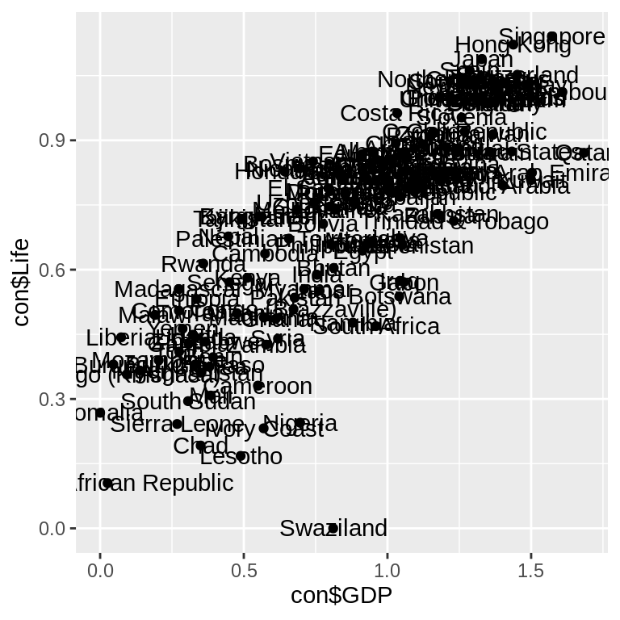

```r
con <- data.frame(wscores,w$Country)
pl1 <- ggplot(con,aes(x=con$GDP,y=con$Life)) + geom_point() + geom_text(aes(label=w$Country))
pl1
```

The pair of variables with the highest correlation are Life and GDP. The outlying country on this graph is Swaziland.

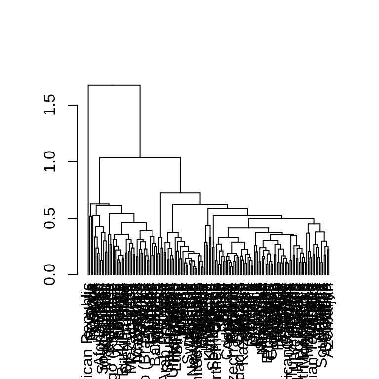

```r
D1 <- as.matrix(dist(wscores,method="euclidean"))
avcl<- hclust(as.dist(D1),"average")
avcld <- as.dendrogram(avcl)
plot(as.dendrogram(avcl))
```

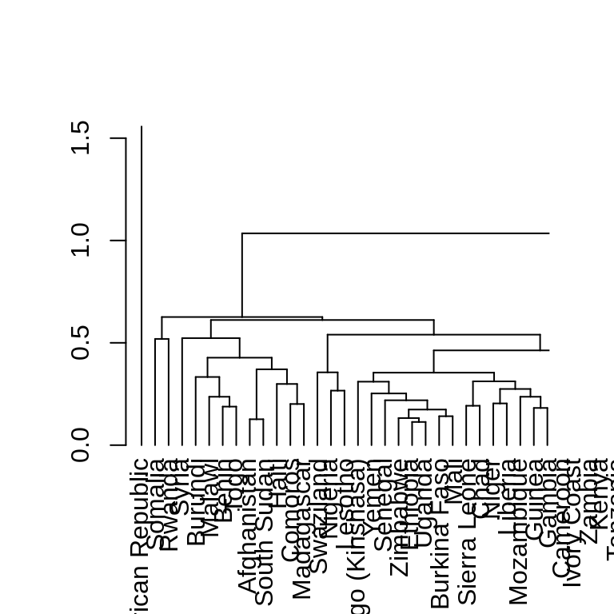

```r
plot(avcld,xlim = c(1,30),ylim = c(0,1.5))
```

Yes,Central African Republic is an Outlier.

```r
library(dendextend)
```

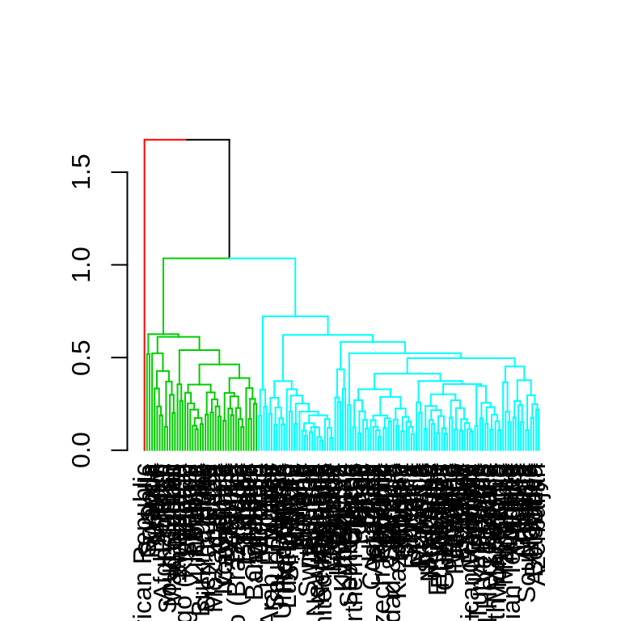

```r
avcld2 <- color_branches(avcld,k=3,col=c(2,3,5))
plot(avcld2)
```

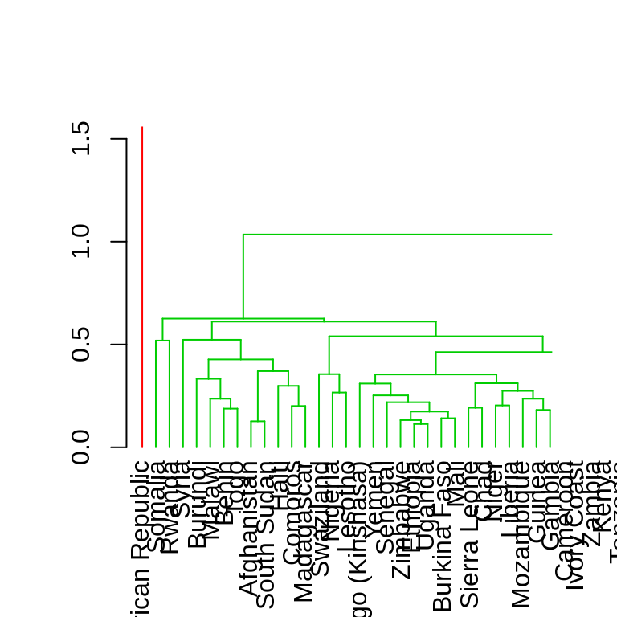

```r
plot(avcld2,xlim = c(1,30),ylim = c(0,1.5))
```

```r
cutree(avcl,3)
```

```
##                  Finland                  Denmark                   Norway
##                        1                        1                        1
##                  Iceland              Netherlands              Switzerland
##                        1                        1                        1
##                   Sweden              New Zealand                   Canada
##                        1                        1                        1
##                  Austria                Australia               Costa Rica
##                        1                        1                        1
##                   Israel               Luxembourg           United Kingdom
##                        1                        1                        1
##                  Ireland                  Germany                  Belgium
##                        1                        1                        1
##            United States           Czech Republic     United Arab Emirates
##                        1                        1                        1
##                    Malta                   Mexico                   France
##                        1                        1                        1
##                   Taiwan                    Chile                Guatemala
##                        1                        1                        1
##             Saudi Arabia                    Qatar                    Spain
##                        1                        1                        1
##                   Panama                   Brazil                  Uruguay
##                        1                        1                        1
##                Singapore              El Salvador                    Italy
##                        1                        1                        1
##                  Bahrain                 Slovakia        Trinidad & Tobago
##                        1                        1                        1
##                   Poland               Uzbekistan                Lithuania
##                        1                        1                        1
##                 Colombia                 Slovenia                Nicaragua
##                        1                        1                        1
##                   Kosovo                Argentina                  Romania
##                        1                        1                        1
##                   Cyprus                  Ecuador                   Kuwait
##                        1                        1                        1
##                 Thailand                   Latvia              South Korea
##                        1                        1                        1
##                  Estonia                  Jamaica                Mauritius
##                        1                        1                        1
##                    Japan                 Honduras               Kazakhstan
##                        1                        1                        1
```

[output cut: 49 more lines]

```
##                        1                        2                        2
##                   Uganda                    Egypt                   Zambia
##                        2                        1                        2
##                     Togo                    India                  Liberia
##                        2                        2                        2
##                  Comoros               Madagascar                  Lesotho
##                        2                        2                        2
##                  Burundi                 Zimbabwe                    Haiti
##                        2                        2                        2
##                 Botswana                    Syria                   Malawi
##                        1                        2                        2
##                    Yemen                   Rwanda                 Tanzania
##                        2                        2                        2
##              Afghanistan Central African Republic              South Sudan
##                        2                        3                        2
```

```r
screeplot <- function(p) {
  e <- p$sdev ^ 2
  e <- e / sum(e)
  plot(
    1:length(e),
    e,
    xlab = "Component number",
    pch = 20,
    ylab = "Variance proportion",
    main = "Scree plot",
    axes = F,
    ylim = c(0, max(e)*1.04)
  )
  lines(1:length(e), e)
  axis(1, at = 1:length(e))
  axis(2)
}

sumPartition <- function(dat,z){
  k <-length(unique(z))
  nobs <- tapply(1:nrow(dat),z,length)
  withinSS <- tapply(1:nrow(dat),z,function(i){
    if (length(i)==1) 0
    else {x<- dat[i,]
    xm <- scale(x, scale=F)
    sum(xm^2)
    }
  })
  aveD <- tapply(1:nrow(dat),z,function(i){
    if (length(i)==1) 0
    else {x<- dat[i,]
    xm <- scale(x, scale=F)
    xm <- apply(xm, 1, function(y) sqrt(sum(y^2)))
    mean(xm)
    }
  })

  maxD <- tapply(1:nrow(dat),z,function(i){
    if (length(i)==1) 0
    else {x<- dat[i,]
    xm <- scale(x, scale=F)
    xm <- apply(xm, 1, function(y) sqrt(sum(y^2)))
    max(xm)
    }
  })

  part<- data.frame("N.obs"=nobs, "Within clus SS" = withinSS, "Ave dist  Centroid" = aveD,
                    "Max dist centroid" =maxD)
  rownames(part)<- paste("Cluster", 1:k)



  cCen <- cbind(simplify2array(tapply(1:nrow(dat),z,function(i){
    x<- dat[i,]
    if (length(i)==1) x
    else {
      colMeans(x)
    }
  })), colMeans(dat))
  colnames(cCen)<- c(paste("Cluster", 1:k), "Grand centrd")

  cCenD <- as.matrix(dist(t(cCen[, -ncol(cCen)])))
  cat("Final Partition\n")
  cat("\n")
  cat(paste("Number of clusters ", k))
  cat("\n")

  cat("\n")
  print(part, quote=F)
  cat("\n")
  cat("\n")
  cat("Cluster centroids\n")
  cat("\n")
  print(cCen,quote=F)
  cat("\n")
  cat("\n")
  cat("Distances between Cluster centroids\n")
  cat("\n")
  print(cCenD,quote=F)
  list(withinSS=withinSS, aveD=aveD, centroids=cCen, centroidDist=cCenD)
}

sumPartition(wscores,cutree(avcl,3))
```

```
## Final Partition
##
## Number of clusters  3
##
##           N.obs Within.clus.SS Ave.dist..Centroid Max.dist.centroid
## Cluster 1   111      16.679440          0.3618240         0.7628128
## Cluster 2    44       6.145732          0.3505806         0.6628750
## Cluster 3     1       0.000000          0.0000000         0.0000000
##
##
## Cluster centroids
##
##            Cluster 1 Cluster 2 Cluster 3 Grand centrd
## GDP        1.11018   0.4078864 0.026     0.9051474
## Family     1.34836   0.88425   0         1.208814
## Life       0.8471712 0.43175   0.105     0.7252436
## Freedom    0.4175405 0.3333864 0.225     0.3925705
## Generosity 0.1738829 0.2113636 0.235     0.1848462
## Trust      0.1148649 0.1015682 0.035     0.1106026
##
##
## Distances between Cluster centroids
##
##           Cluster 1 Cluster 2 Cluster 3
## Cluster 1 0.0000000 0.9433204  1.895132
## Cluster 2 0.9433204 0.0000000  1.025299
## Cluster 3 1.8951322 1.0252992  0.000000
```

```
## $withinSS
##         1         2         3
## 16.679440  6.145732  0.000000
##
## $aveD
##         1         2         3
## 0.3618240 0.3505806 0.0000000
##
## $centroids
##            Cluster 1 Cluster 2 Cluster 3 Grand centrd
## GDP        1.11018   0.4078864 0.026     0.9051474
## Family     1.34836   0.88425   0         1.208814
## Life       0.8471712 0.43175   0.105     0.7252436
## Freedom    0.4175405 0.3333864 0.225     0.3925705
## Generosity 0.1738829 0.2113636 0.235     0.1848462
## Trust      0.1148649 0.1015682 0.035     0.1106026
##
## $centroidDist
##           Cluster 1 Cluster 2 Cluster 3
## Cluster 1 0.0000000 0.9433204  1.895132
## Cluster 2 0.9433204 0.0000000  1.025299
## Cluster 3 1.8951322 1.0252992  0.000000
```

The cluster sizes are 111 in cluster1, 44 in cluster2 and 1 in cluster3. Total countries in three cluster solution is 156. Ireland belongs to cluster: 1. India belongs to cluster: 2. Cluster 1 has the highest Family score. Cluster 1 has the highest scores overall.

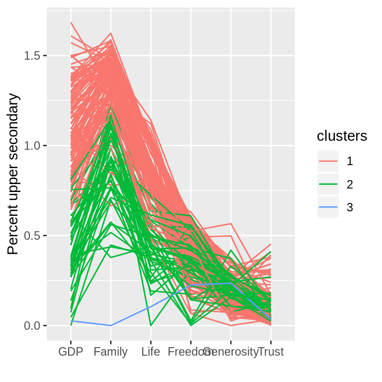

```r
wscores1 <- wscores
wscores1$clusters <- as.factor(cutree(avcl,3))
ggparcoord(wscores1, columns=1:6, groupColumn="clusters", scale="globalminmax")+
xlab("")+ylab("Percent upper secondary")
```

```r
set.seed(123)
kmen <- kmeans(wscores,3,nstart= 10)
tabform<-table(con$w.Country,kmen$cluster)
tabform
```

```
##
##                            1 2 3
##   Afghanistan              0 0 1
##   Albania                  0 1 0
##   Algeria                  0 1 0
##   Argentina                0 1 0
##   Armenia                  0 1 0
##   Australia                1 0 0
##   Austria                  1 0 0
##   Azerbaijan               0 1 0
##   Bahrain                  1 0 0
##   Bangladesh               0 0 1
##   Belarus                  0 1 0
##   Belgium                  1 0 0
##   Benin                    0 0 1
##   Bhutan                   0 1 0
##   Bolivia                  0 1 0
##   Bosnia and Herzegovina   0 1 0
##   Botswana                 0 1 0
##   Brazil                   0 1 0
##   Bulgaria                 0 1 0
##   Burkina Faso             0 0 1
##   Burundi                  0 0 1
##   Cambodia                 0 1 0
##   Cameroon                 0 0 1
##   Canada                   1 0 0
##   Central African Republic 0 0 1
##   Chad                     0 0 1
##   Chile                    1 0 0
##   China                    0 1 0
##   Colombia                 0 1 0
##   Comoros                  0 0 1
##   Congo (Brazzaville)      0 0 1
##   Congo (Kinshasa)         0 0 1
##   Costa Rica               1 0 0
##   Croatia                  0 1 0
##   Cyprus                   1 0 0
##   Czech Republic           1 0 0
##   Denmark                  1 0 0
##   Dominican Republic       0 1 0
```

[output cut: 103 more lines]

```
##   Tunisia                  0 1 0
##   Turkey                   0 1 0
##   Turkmenistan             0 1 0
##   Uganda                   0 0 1
##   Ukraine                  0 1 0
##   United Arab Emirates     1 0 0
##   United Kingdom           1 0 0
##   United States            1 0 0
##   Uruguay                  1 0 0
##   Uzbekistan               0 1 0
##   Venezuela                0 1 0
##   Vietnam                  0 1 0
##   Yemen                    0 0 1
##   Zambia                   0 0 1
##   Zimbabwe                 0 0 1
```

No,There are no outlier countries.

```r
kme2 <- as.factor(kmen$cluster)
we1 <- data.frame(con,kme2)
head(we1)
```

```
##               GDP Family  Life Freedom Generosity Trust   w.Country kme2
## Finland     1.340  1.587 0.986   0.596      0.153 0.393     Finland    1
## Denmark     1.383  1.573 0.996   0.592      0.252 0.410     Denmark    1
## Norway      1.488  1.582 1.028   0.603      0.271 0.341      Norway    1
## Iceland     1.380  1.624 1.026   0.591      0.354 0.118     Iceland    1
## Netherlands 1.396  1.522 0.999   0.557      0.322 0.298 Netherlands    1
## Switzerland 1.452  1.526 1.052   0.572      0.263 0.343 Switzerland    1
```

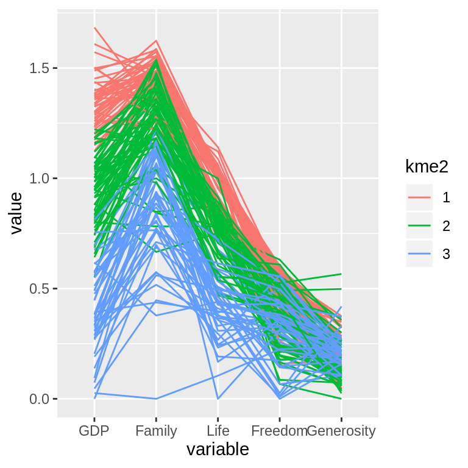

```r
ggparcoord(we1,columns=1:5, groupColumn="kme2",scale="globalminmax")
```

```r
sumPartition(wscores,kmen$cluster)
```

```
## Final Partition
##
## Number of clusters  3
##
##           N.obs Within.clus.SS Ave.dist..Centroid Max.dist.centroid
## Cluster 1    48       3.261740          0.2499082         0.4228718
## Cluster 2    64       6.545869          0.3021908         0.6165757
## Cluster 3    44       6.909874          0.3640020         0.9934354
##
##
## Cluster centroids
##
##            Cluster 1  Cluster 2  Cluster 3 Grand centrd
## GDP        1.3341875 0.93682813 0.39102273    0.9051474
## Family     1.4569375 1.26125000 0.86186364    1.2088141
## Life       0.9596458 0.76050000 0.41825000    0.7252436
## Freedom    0.4763542 0.38393750 0.31372727    0.3925705
## Generosity 0.2004375 0.15737500 0.20779545    0.1848462
## Trust      0.1739583 0.07090625 0.09922727    0.1106026
##
##
## Distances between Cluster centroids
##
##           Cluster 1 Cluster 2 Cluster 3
## Cluster 1 0.0000000 0.5068156 1.2525448
## Cluster 2 0.5068156 0.0000000 0.7634277
## Cluster 3 1.2525448 0.7634277 0.0000000
```

```
## $withinSS
##        1        2        3
## 3.261740 6.545869 6.909874
##
## $aveD
##         1         2         3
## 0.2499082 0.3021908 0.3640020
##
## $centroids
##            Cluster 1  Cluster 2  Cluster 3 Grand centrd
## GDP        1.3341875 0.93682813 0.39102273    0.9051474
## Family     1.4569375 1.26125000 0.86186364    1.2088141
## Life       0.9596458 0.76050000 0.41825000    0.7252436
## Freedom    0.4763542 0.38393750 0.31372727    0.3925705
## Generosity 0.2004375 0.15737500 0.20779545    0.1848462
## Trust      0.1739583 0.07090625 0.09922727    0.1106026
##
## $centroidDist
##           Cluster 1 Cluster 2 Cluster 3
## Cluster 1 0.0000000 0.5068156 1.2525448
## Cluster 2 0.5068156 0.0000000 0.7634277
## Cluster 3 1.2525448 0.7634277 0.0000000
```

Cluster 1 has the highest Family score. Cluster 1 has the highest scores overall.

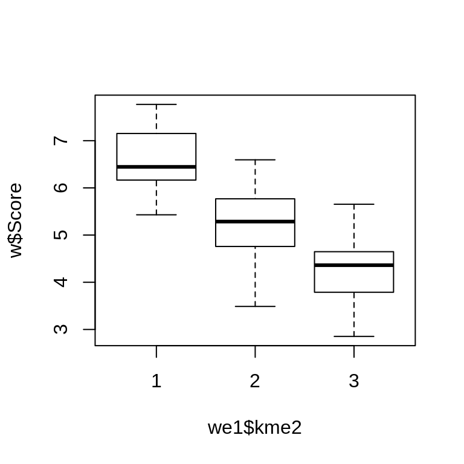

```r
boxplot(w$Score~we1$kme2)
```

The Highest scores follows the pattern of cluster1 then cluster2 and then cluster3.Mean of cluster1 is in range 6-7, for cluster2 within 5-6 and cluster3 within 4-5.